# Predict Bike Sharing Demand with AutoGluon Template

## Project: Predict Bike Sharing Demand with AutoGluon

This notebook is a template with each step that you need to complete for the project.

Please fill in your code where there are explicit `?` markers in the notebook. You are welcome to add more cells and code as you see fit.

Once you have completed all the code implementations, please export your notebook as a HTML file so the reviews can view your code. Make sure you have all outputs correctly outputted.

`File-> Export Notebook As... -> Export Notebook as HTML`

There is a writeup to complete as well after all code implememtation is done. Please answer all questions and attach the necessary tables and charts. You can complete the writeup in either markdown or PDF.

Completing the code template and writeup template will cover all of the rubric points for this project.

The rubric contains "Stand Out Suggestions" for enhancing the project beyond the minimum requirements. The stand out suggestions are optional. If you decide to pursue the "stand out suggestions", you can include the code in this notebook and also discuss the results in the writeup file.

## Step 1: Create an account with Kaggle

### Create Kaggle Account and download API key

Below is example of steps to get the API username and key. Each student will have their own username and key.

1. Open account settings.

2. Scroll down to API and click Create New API Token.

3. Open up `kaggle.json` and use the username and key.


## Step 2: Download the Kaggle dataset using the kaggle python library

### Open up Sagemaker Studio and use starter template

1. Notebook should be using a `ml.t3.medium` instance (2 vCPU + 4 GiB)
2. Notebook should be using kernal: `Python 3 (MXNet 1.8 Python 3.7 CPU Optimized)`

```python
!mkdir -p /root/.kaggle
!touch /root/.kaggle/kaggle.json
!chmod 600 /root/.kaggle/kaggle.json
```

### Install packages

```python
!pip install -U pip
!pip install -U setuptools wheel
!pip install -U "mxnet<2.0.0" bokeh==2.0.1
!pip install autogluon --no-cache-dir
# Without --no-cache-dir, smaller aws instances may have trouble installing
```

[output not shown]

### Setup Kaggle API Key

```python
# create the .kaggle directory and an empty kaggle.json file
!mkdir -p /root/.kaggle
!touch /root/.kaggle/kaggle.json
!chmod 600 /root/.kaggle/kaggle.json
```

```python
# Fill in your user name and key from creating the kaggle account and API token file
import json
kaggle_username = "omarkhalil10"
kaggle_key = "0a45dfff9a5547405fe7273b660d07cc"

# Save API token the kaggle.json file
with open("/root/.kaggle/kaggle.json", "w") as f:
    f.write(json.dumps({"username": kaggle_username, "key": kaggle_key}))
```

### Download and explore dataset

### Go to the bike sharing demand competition and agree to the terms

```python
!pip install -U kaggle
```

[output not shown]

```python
# Download the dataset, it will be in a .zip file so you'll need to unzip it as well.
!kaggle competitions download -c bike-sharing-demand
# If you already downloaded it you can use the -o command to overwrite the file
!unzip -o bike-sharing-demand.zip
```

```
Downloading bike-sharing-demand.zip to /root/Bike-Sharing-Demand/project
Archive:  bike-sharing-demand.zip
  inflating: sampleSubmission.csv
  inflating: test.csv
  inflating: train.csv
```

```python
import pandas as pd
from autogluon.tabular import TabularPredictor
```

[figure not shown]

```python
# Create the train dataset in pandas by reading the csv
# Set the parsing of the datetime column so you can use some of the `dt` features in pandas later
train = pd.read_csv('train.csv')
train.head()
```

|  | datetime | season | holiday | workingday | weather | temp | atemp | humidity | windspeed | casual | registered | count |
| --- | --- | --- | --- | --- | --- | --- | --- | --- | --- | --- | --- | --- |
| 0 | 2011-01-01 00:00:00 | 1 | 0 | 0 | 1 | 9.84 | 14.395 | 81 | 0.0 | 3 | 13 | 16 |
| 1 | 2011-01-01 01:00:00 | 1 | 0 | 0 | 1 | 9.02 | 13.635 | 80 | 0.0 | 8 | 32 | 40 |
| 2 | 2011-01-01 02:00:00 | 1 | 0 | 0 | 1 | 9.02 | 13.635 | 80 | 0.0 | 5 | 27 | 32 |
| 3 | 2011-01-01 03:00:00 | 1 | 0 | 0 | 1 | 9.84 | 14.395 | 75 | 0.0 | 3 | 10 | 13 |
| 4 | 2011-01-01 04:00:00 | 1 | 0 | 0 | 1 | 9.84 | 14.395 | 75 | 0.0 | 0 | 1 | 1 |

```python
# Simple output of the train dataset to view some of the min/max/varition of the dataset features.
```

[output not shown]

```python
# Create the test pandas dataframe in pandas by reading the csv, remember to parse the datetime!
test = pd.read_csv('test.csv')
test.head()
```

|  | datetime | season | holiday | workingday | weather | temp | atemp | humidity | windspeed |
| --- | --- | --- | --- | --- | --- | --- | --- | --- | --- |
| 0 | 2011-01-20 00:00:00 | 1 | 0 | 1 | 1 | 10.66 | 11.365 | 56 | 26.0027 |
| 1 | 2011-01-20 01:00:00 | 1 | 0 | 1 | 1 | 10.66 | 13.635 | 56 | 0.0000 |
| 2 | 2011-01-20 02:00:00 | 1 | 0 | 1 | 1 | 10.66 | 13.635 | 56 | 0.0000 |
| 3 | 2011-01-20 03:00:00 | 1 | 0 | 1 | 1 | 10.66 | 12.880 | 56 | 11.0014 |
| 4 | 2011-01-20 04:00:00 | 1 | 0 | 1 | 1 | 10.66 | 12.880 | 56 | 11.0014 |

```python
# Same thing as train and test dataset
submission = pd.read_csv('sampleSubmission.csv')
submission.head()
```

|  | datetime | count |
| --- | --- | --- |
| 0 | 2011-01-20 00:00:00 | 0 |
| 1 | 2011-01-20 01:00:00 | 0 |
| 2 | 2011-01-20 02:00:00 | 0 |
| 3 | 2011-01-20 03:00:00 | 0 |
| 4 | 2011-01-20 04:00:00 | 0 |

## Step 3: Train a model using AutoGluon’s Tabular Prediction

Requirements:

- We are prediting `count`, so it is the label we are setting.
- Ignore `casual` and `registered` columns as they are also not present in the test dataset.
- Use the `root_mean_squared_error` as the metric to use for evaluation.
- Set a time limit of 10 minutes (600 seconds).
- Use the preset `best_quality` to focus on creating the best model.

```python
predictor = TabularPredictor(label="count", problem_type="regression", eval_metric="rmse").fit(train_data=train.drop(['casual', 'registered'], axis=1), time_limit=600, presets='best_quality')
```

```
No path specified. Models will be saved in: "AutogluonModels/ag-20230531_050418/"
Presets specified: ['best_quality']
Stack configuration (auto_stack=True): num_stack_levels=1, num_bag_folds=8, num_bag_sets=20
Beginning AutoGluon training ... Time limit = 600s
AutoGluon will save models to "AutogluonModels/ag-20230531_050418/"
AutoGluon Version:  0.7.0
Python Version:     3.8.10
Operating System:   Linux
Platform Machine:   x86_64
Platform Version:   #1 SMP Tue Apr 25 15:24:19 UTC 2023
Train Data Rows:    10886
Train Data Columns: 9
Label Column: count
Preprocessing data ...
Using Feature Generators to preprocess the data ...
Fitting AutoMLPipelineFeatureGenerator...
	Available Memory:                    2901.8 MB
	Train Data (Original)  Memory Usage: 1.52 MB (0.1% of available memory)
	Inferring data type of each feature based on column values. Set feature_metadata_in to manually specify special dtypes of the features.
	Stage 1 Generators:
		Fitting AsTypeFeatureGenerator...
			Note: Converting 2 features to boolean dtype as they only contain 2 unique values.
	Stage 2 Generators:
		Fitting FillNaFeatureGenerator...
	Stage 3 Generators:
		Fitting IdentityFeatureGenerator...
		Fitting DatetimeFeatureGenerator...
	Stage 4 Generators:
		Fitting DropUniqueFeatureGenerator...
	Types of features in original data (raw dtype, special dtypes):
		('float', [])                      : 3 | ['temp', 'atemp', 'windspeed']
		('int', [])                        : 5 | ['season', 'holiday', 'workingday', 'weather', 'humidity']
		('object', ['datetime_as_object']) : 1 | ['datetime']
	Types of features in processed data (raw dtype, special dtypes):
		('float', [])                : 3 | ['temp', 'atemp', 'windspeed']
		('int', [])                  : 3 | ['season', 'weather', 'humidity']
		('int', ['bool'])            : 2 | ['holiday', 'workingday']
		('int', ['datetime_as_int']) : 5 | ['datetime', 'datetime.year', 'datetime.month', 'datetime.day', 'datetime.dayofweek']
	0.2s = Fit runtime
	9 features in original data used to generate 13 features in processed data.
```

[output cut: 190 more lines]

[output not shown]

### Review AutoGluon's training run with ranking of models that did the best.

```python
predictor.fit_summary()
```

```
*** Summary of fit() ***
Estimated performance of each model:
                     model   score_val  pred_time_val    fit_time  pred_time_val_marginal  fit_time_marginal  stack_level  can_infer  fit_order
0      WeightedEnsemble_L3  -52.836260      14.334746  427.505218                0.000785           0.377218            3       True         17
1   RandomForestMSE_BAG_L2  -53.482038      13.330259  378.315029                0.613817          27.886582            2       True         13
2     ExtraTreesMSE_BAG_L2  -53.756244      13.305077  358.600347                0.588635           8.171900            2       True         15
3          LightGBM_BAG_L2  -55.087506      12.935886  370.218732                0.219444          19.790285            2       True         12
4           XGBoost_BAG_L2  -55.179288      12.912066  371.279233                0.195624          20.850786            2       True         16
5          CatBoost_BAG_L2  -55.789131      12.783301  422.929563                0.066859          72.501116            2       True         14
6        LightGBMXT_BAG_L2  -60.307175      16.362878  398.870867                3.646436          48.442420            2       True         11
7    KNeighborsDist_BAG_L1  -84.125061       0.039495    0.033504                0.039495           0.033504            1       True          2
8      WeightedEnsemble_L2  -84.125061       0.040518    0.521746                0.001023           0.488241            2       True         10
9    KNeighborsUnif_BAG_L1 -101.546199       0.040225    0.033063                0.040225           0.033063            1       True          1
10  RandomForestMSE_BAG_L1 -116.544294       0.544561   11.192899                0.544561          11.192899            1       True          5
11    ExtraTreesMSE_BAG_L1 -124.588053       0.523096    4.752613                0.523096           4.752613            1       True          7
12    LightGBMLarge_BAG_L1 -130.132290       1.104624   28.315002                1.104624          28.315002            1       True          9
13         CatBoost_BAG_L1 -130.493223       0.106977  200.173105                0.106977         200.173105            1       True          6
14         LightGBM_BAG_L1 -131.054162       1.454303   23.223164                1.454303          23.223164            1       True          4
15       LightGBMXT_BAG_L1 -131.460909       8.431393   59.408019                8.431393          59.408019            1       True          3
16          XGBoost_BAG_L1 -131.624665       0.471769   23.297078                0.471769          23.297078            1       True          8
Number of models trained: 17
Types of models trained:
{'StackerEnsembleModel_XT', 'StackerEnsembleModel_KNN', 'StackerEnsembleModel_CatBoost', 'StackerEnsembleModel_RF', 'WeightedEnsembleModel', 'StackerEnsembleModel_XGBoost', 'StackerEnsembleModel_LGB'}
Bagging used: True  (with 8 folds)
Multi-layer stack-ensembling used: True  (with 3 levels)
Feature Metadata (Processed):
(raw dtype, special dtypes):
('float', [])                : 3 | ['temp', 'atemp', 'windspeed']
('int', [])                  : 3 | ['season', 'weather', 'humidity']
('int', ['bool'])            : 2 | ['holiday', 'workingday']
('int', ['datetime_as_int']) : 5 | ['datetime', 'datetime.year', 'datetime.month', 'datetime.day', 'datetime.dayofweek']
Plot summary of models saved to file: AutogluonModels/ag-20230531_050418/SummaryOfModels.html
*** End of fit() summary ***
```

[output not shown]

[output cut: 163 more lines]

```
 2          15
 3          12
 4          16
 5          14
 6          11
 7           2
 8          10
 9           1
 10          5
 11          7
 12          9
 13          6
 14          4
 15          3
 16          8  }
```

### Create predictions from test dataset

```python
# Make predictions
predictions = predictor.predict(test)

# Create DataFrame
predictions = pd.DataFrame({'datetime': test['datetime'], 'Pred_count': predictions})

# Display the first few rows of the DataFrame
predictions.head()
```

|  | datetime | Pred_count |
| --- | --- | --- |
| 0 | 2011-01-20 00:00:00 | 23.471445 |
| 1 | 2011-01-20 01:00:00 | 41.856407 |
| 2 | 2011-01-20 02:00:00 | 46.169731 |
| 3 | 2011-01-20 03:00:00 | 49.140942 |
| 4 | 2011-01-20 04:00:00 | 52.903252 |

#### NOTE: Kaggle will reject the submission if we don't set everything to be > 0.

```python
# Describe the `predictions` series to see if there are any negative values
predictions.describe()
```

|  | Pred_count |
| --- | --- |
| count | 6493.000000 |
| mean | 100.750656 |
| std | 90.407387 |
| min | 3.141485 |
| 25% | 20.263681 |
| 50% | 63.079163 |
| 75% | 171.432785 |
| max | 364.252838 |

```python
# How many negative values do we have?
# Group by 'Pred_count' and calculate the sum of negative values within each group
neg_count = predictions.groupby('Pred_count')['Pred_count'].agg([('negcount', lambda x: (x < 0).sum())])

print(neg_count)
```

```
            negcount
Pred_count
3.141485           0
3.144719           0
3.193251           0
3.205677           0
3.212598           0
...              ...
363.342804         0
363.543182         0
363.955139         0
364.067047         0
364.252838         0

[6243 rows x 1 columns]
```

```python
# Set them to zero
predictions.loc[predictions['Pred_count'] < 0, 'Pred_count'] = 0
```

### Set predictions to submission dataframe, save, and submit

```python
submission["count"] = predictions['Pred_count']
submission.to_csv("submission.csv", index=False)
```

```python
!kaggle competitions submit -c bike-sharing-demand -f submission.csv -m "first raw submission"
```

```
Successfully submitted to Bike Sharing Demand
```

#### View submission via the command line or in the web browser under the competition's page - `My Submissions`

```python
!kaggle competitions submissions -c bike-sharing-demand | tail -n +1 | head -n 6
```

```
fileName                     date                 description                        status    publicScore  privateScore
---------------------------  -------------------  ---------------------------------  --------  -----------  ------------
submission.csv               2023-05-31 05:15:18  first raw submission               complete  1.81426      1.81426
submission_new_hpo.csv       2023-05-31 02:47:01  new features with hyperparameters  complete  0.48815      0.48815
submission_new_hpo.csv       2023-05-31 02:31:59  new features with hyperparameters  complete  0.48815      0.48815
submission_new_features.csv  2023-05-31 02:20:01  new features                       complete  0.69748      0.69748
```

#### Initial score of `1.81426`

## Step 4: Exploratory Data Analysis and Creating an additional feature

- Any additional feature will do, but a great suggestion would be to separate out the datetime into hour, day, or month parts.

[figure not shown]

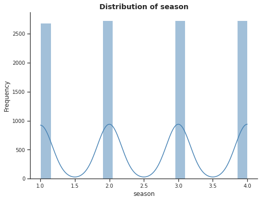

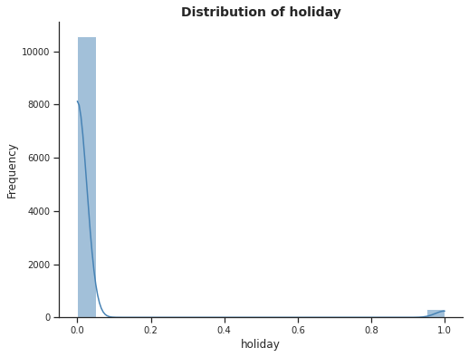

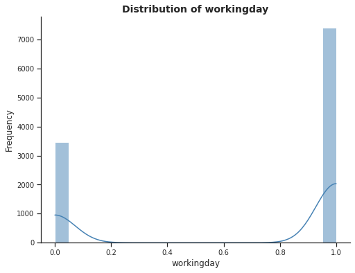

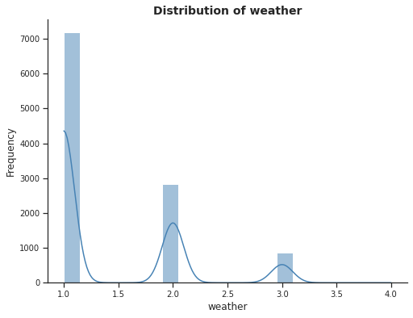

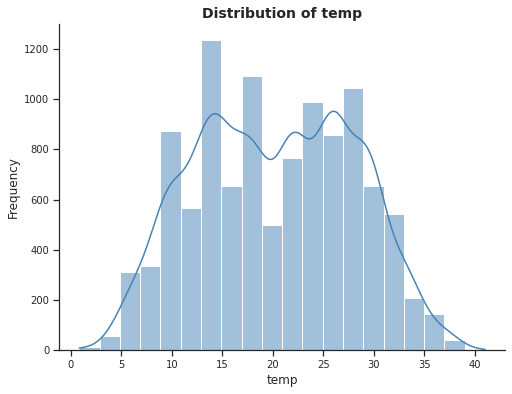

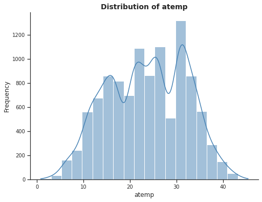

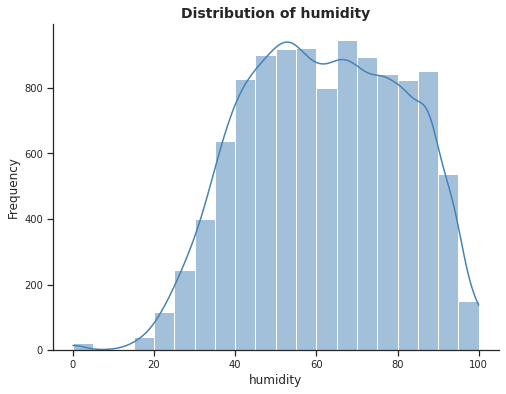

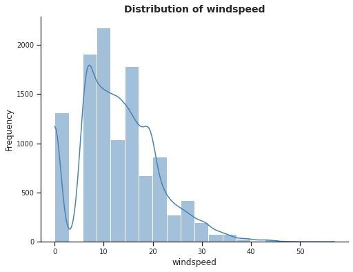

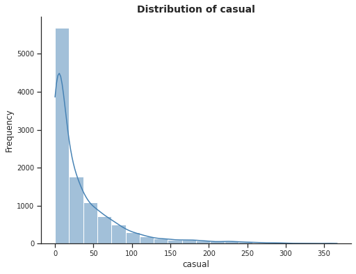

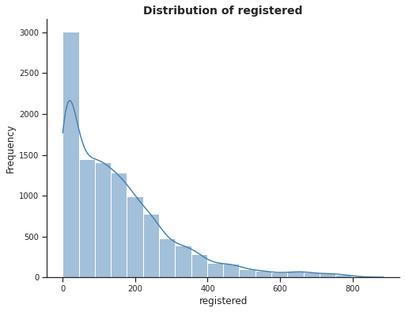

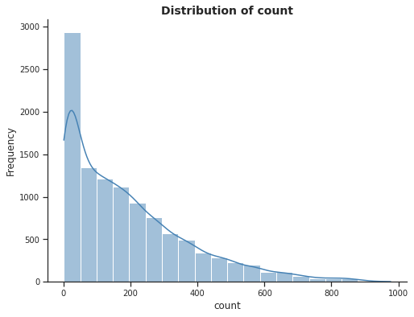

```python
# Create a histogram of all features to show the distribution of each one relative to the data. This is part of the exploritory data analysis
import matplotlib.pyplot as plt
import seaborn as sns

# Set the style and context for the plots
sns.set(style='ticks', context='notebook')

# Define the number of bins for the histogram
num_bins = 20

# Iterate over each column in the DataFrame
for column in train.columns:
    # Create a histogram for the current feature
    plt.figure(figsize=(8, 6))
    sns.histplot(data=train, x=column, bins=num_bins, kde=True, color='steelblue')

    # Set labels and title for the histogram
    plt.xlabel(column, fontsize=12)
    plt.ylabel('Frequency', fontsize=12)
    plt.title(f'Distribution of {column}', fontsize=14, fontweight='bold')

    # Set the x-axis and y-axis tick font sizes
    plt.xticks(fontsize=10)
    plt.yticks(fontsize=10)

    # Remove the top and right spines
    sns.despine()

    # Display the histogram
    plt.show()
```

```python
# create a new feature
# Convert 'datetime' column to datetime data type in train DataFrame
train.loc[:, "datetime"] = pd.to_datetime(train.loc[:, "datetime"])

# Convert 'datetime' column to datetime data type in test DataFrame
test.loc[:, "datetime"] = pd.to_datetime(test.loc[:, "datetime"])

# Extract year, month, day, and hour from 'datetime' column in train DataFrame
train['year'] = train['datetime'].dt.year
train['month'] = train['datetime'].dt.month
train['day'] = train['datetime'].dt.day
train['hour'] = train['datetime'].dt.hour

# Extract year, month, day, and hour from 'datetime' column in test DataFrame
test['year'] = test['datetime'].dt.year
test['month'] = test['datetime'].dt.month
test['day'] = test['datetime'].dt.day
test['hour'] = test['datetime'].dt.hour
```

## Make category types for these so models know they are not just numbers

- AutoGluon originally sees these as ints, but in reality they are int representations of a category.
- Setting the dtype to category will classify these as categories in AutoGluon.

```python
# Convert 'season' column to categorical data type in train DataFrame
train["season"] = train["season"].astype("category")

# Convert 'weather' column to categorical data type in train DataFrame
train["weather"] = train["weather"].astype("category")

# Convert 'season' column to categorical data type in test DataFrame
test["season"] = test["season"].astype("category")

# Convert 'weather' column to categorical data type in test DataFrame
test["weather"] = test["weather"].astype("category")
```

```python
# View are new feature
train.head()
```

|  | datetime | season | holiday | workingday | weather | temp | atemp | humidity | windspeed | casual | registered | count | year | month | day | hour |
| --- | --- | --- | --- | --- | --- | --- | --- | --- | --- | --- | --- | --- | --- | --- | --- | --- |
| 0 | 2011-01-01 00:00:00 | 1 | 0 | 0 | 1 | 9.84 | 14.395 | 81 | 0.0 | 3 | 13 | 16 | 2011 | 1 | 1 | 0 |
| 1 | 2011-01-01 01:00:00 | 1 | 0 | 0 | 1 | 9.02 | 13.635 | 80 | 0.0 | 8 | 32 | 40 | 2011 | 1 | 1 | 1 |
| 2 | 2011-01-01 02:00:00 | 1 | 0 | 0 | 1 | 9.02 | 13.635 | 80 | 0.0 | 5 | 27 | 32 | 2011 | 1 | 1 | 2 |
| 3 | 2011-01-01 03:00:00 | 1 | 0 | 0 | 1 | 9.84 | 14.395 | 75 | 0.0 | 3 | 10 | 13 | 2011 | 1 | 1 | 3 |
| 4 | 2011-01-01 04:00:00 | 1 | 0 | 0 | 1 | 9.84 | 14.395 | 75 | 0.0 | 0 | 1 | 1 | 2011 | 1 | 1 | 4 |

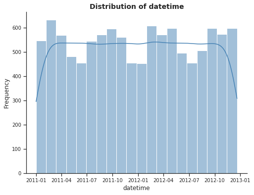

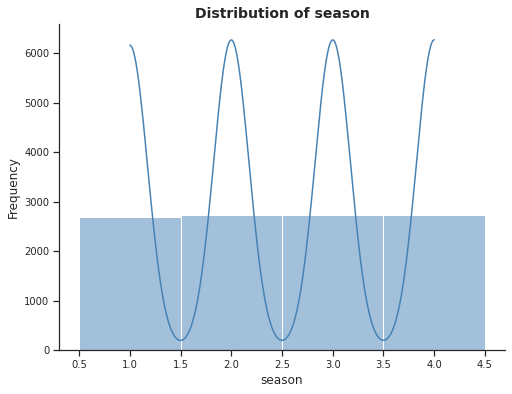

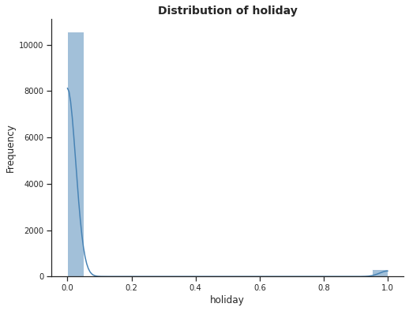

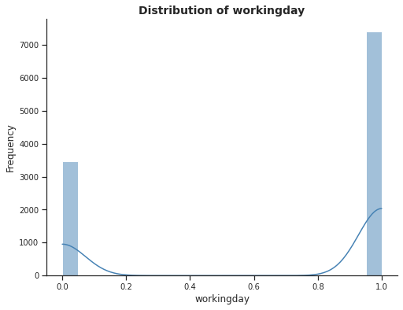

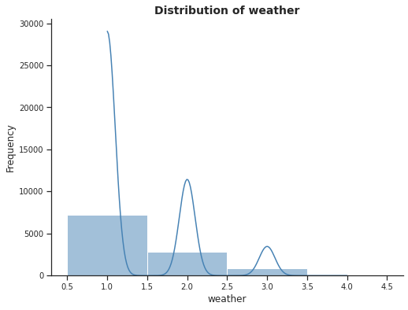

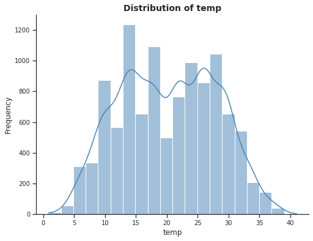

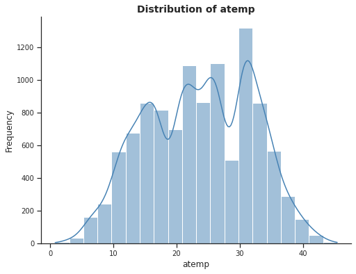

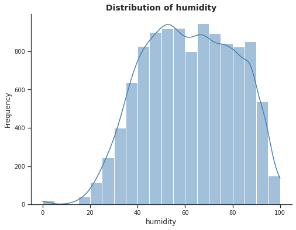

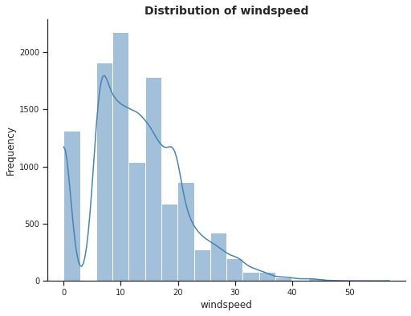

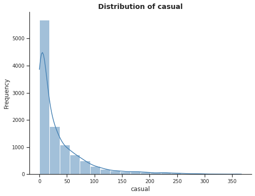

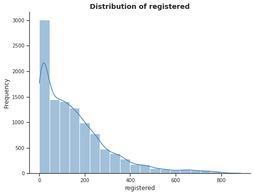

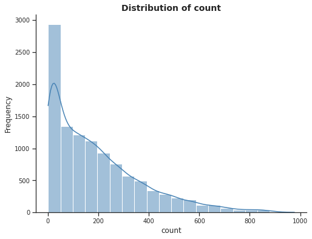

[4 more figures not shown]

```python
# View histogram of all features again now with the hour feature
# Set the style and context for the plots
sns.set(style='ticks', context='notebook')

# Define the number of bins for the histogram
num_bins = 20

# Iterate over each column in the DataFrame
for column in train.columns:
    # Create a histogram for the current feature
    plt.figure(figsize=(8, 6))
    sns.histplot(data=train, x=column, bins=num_bins, kde=True, color='steelblue')

    # Set labels and title for the histogram
    plt.xlabel(column, fontsize=12)
    plt.ylabel('Frequency', fontsize=12)
    plt.title(f'Distribution of {column}', fontsize=14, fontweight='bold')

    # Set the x-axis and y-axis tick font sizes
    plt.xticks(fontsize=10)
    plt.yticks(fontsize=10)

    # Remove the top and right spines
    sns.despine()

    # Display the histogram
    plt.show()
```

## Step 5: Rerun the model with the same settings as before, just with more features

```python
predictor_new_features = TabularPredictor(label="count", problem_type="regression", eval_metric="rmse").fit(train_data=train.drop(['casual', 'registered'], axis=1), time_limit=600, presets='best_quality')
```

```
No path specified. Models will be saved in: "AutogluonModels/ag-20230531_051743/"
Presets specified: ['best_quality']
Stack configuration (auto_stack=True): num_stack_levels=1, num_bag_folds=8, num_bag_sets=20
Beginning AutoGluon training ... Time limit = 600s
AutoGluon will save models to "AutogluonModels/ag-20230531_051743/"
AutoGluon Version:  0.7.0
Python Version:     3.8.10
Operating System:   Linux
Platform Machine:   x86_64
Platform Version:   #1 SMP Tue Apr 25 15:24:19 UTC 2023
Train Data Rows:    10886
Train Data Columns: 13
Label Column: count
Preprocessing data ...
Using Feature Generators to preprocess the data ...
Fitting AutoMLPipelineFeatureGenerator...
	Available Memory:                    1882.94 MB
	Train Data (Original)  Memory Usage: 0.98 MB (0.1% of available memory)
	Inferring data type of each feature based on column values. Set feature_metadata_in to manually specify special dtypes of the features.
	Stage 1 Generators:
		Fitting AsTypeFeatureGenerator...
			Note: Converting 3 features to boolean dtype as they only contain 2 unique values.
	Stage 2 Generators:
		Fitting FillNaFeatureGenerator...
	Stage 3 Generators:
		Fitting IdentityFeatureGenerator...
		Fitting CategoryFeatureGenerator...
			Fitting CategoryMemoryMinimizeFeatureGenerator...
		Fitting DatetimeFeatureGenerator...
	Stage 4 Generators:
		Fitting DropUniqueFeatureGenerator...
	Types of features in original data (raw dtype, special dtypes):
		('category', []) : 2 | ['season', 'weather']
		('datetime', []) : 1 | ['datetime']
		('float', [])    : 3 | ['temp', 'atemp', 'windspeed']
		('int', [])      : 7 | ['holiday', 'workingday', 'humidity', 'year', 'month', ...]
	Types of features in processed data (raw dtype, special dtypes):
		('category', [])             : 2 | ['season', 'weather']
		('float', [])                : 3 | ['temp', 'atemp', 'windspeed']
		('int', [])                  : 4 | ['humidity', 'month', 'day', 'hour']
```

[output cut: 105 more lines]

```
	Fitting 8 child models (S1F1 - S1F8) | Fitting with ParallelLocalFoldFittingStrategy
	-30.5611	 = Validation score   (-root_mean_squared_error)
	88.69s	 = Training   runtime
	0.09s	 = Validation runtime
Fitting model: ExtraTreesMSE_BAG_L2 ... Training model for up to 11.35s of the 11.33s of remaining time.
	-31.4331	 = Validation score   (-root_mean_squared_error)
	9.33s	 = Training   runtime
	0.61s	 = Validation runtime
Completed 1/20 k-fold bagging repeats ...
Fitting model: WeightedEnsemble_L3 ... Training model for up to 360.0s of the -1.04s of remaining time.
	-30.2528	 = Validation score   (-root_mean_squared_error)
	0.78s	 = Training   runtime
	0.0s	 = Validation runtime
AutoGluon training complete, total runtime = 601.99s ... Best model: "WeightedEnsemble_L3"
TabularPredictor saved. To load, use: predictor = TabularPredictor.load("AutogluonModels/ag-20230531_051743/")
```

```python
predictor_new_features.fit_summary()
```

```
*** Summary of fit() ***
Estimated performance of each model:
                     model   score_val  pred_time_val    fit_time  pred_time_val_marginal  fit_time_marginal  stack_level  can_infer  fit_order
0      WeightedEnsemble_L3  -30.252756      20.912510  547.031921                0.000845           0.778652            3       True         15
1          CatBoost_BAG_L2  -30.561084      19.194402  472.937841                0.090987          88.685449            2       True         13
2          LightGBM_BAG_L2  -30.590662      19.447316  404.944660                0.343901          20.692268            2       True         11
3        LightGBMXT_BAG_L2  -31.335904      19.860866  405.661055                0.757451          21.408663            2       True         10
4     ExtraTreesMSE_BAG_L2  -31.433053      19.716624  393.579657                0.613209           9.327266            2       True         14
5   RandomForestMSE_BAG_L2  -31.606340      19.719326  415.466889                0.615911          31.214497            2       True         12
6      WeightedEnsemble_L2  -32.081867      18.514642  378.596026                0.001046           0.453957            2       True          9
7          CatBoost_BAG_L1  -33.910860       0.240919  217.630568                0.240919         217.630568            1       True          6
8          LightGBM_BAG_L1  -33.917339       3.027909   37.110834                3.027909          37.110834            1       True          4
9        LightGBMXT_BAG_L1  -34.345997      13.498143   79.629953               13.498143          79.629953            1       True          3
10          XGBoost_BAG_L1  -34.630648       1.114321   28.605266                1.114321          28.605266            1       True          8
11    ExtraTreesMSE_BAG_L1  -38.295243       0.542549    6.072689                0.542549           6.072689            1       True          7
12  RandomForestMSE_BAG_L1  -38.314947       0.583300   15.130316                0.583300          15.130316            1       True          5
13   KNeighborsDist_BAG_L1  -84.125061       0.049004    0.035132                0.049004           0.035132            1       True          2
14   KNeighborsUnif_BAG_L1 -101.546199       0.047271    0.037633                0.047271           0.037633            1       True          1
Number of models trained: 15
Types of models trained:
{'StackerEnsembleModel_XT', 'StackerEnsembleModel_KNN', 'StackerEnsembleModel_CatBoost', 'StackerEnsembleModel_RF', 'WeightedEnsembleModel', 'StackerEnsembleModel_XGBoost', 'StackerEnsembleModel_LGB'}
Bagging used: True  (with 8 folds)
Multi-layer stack-ensembling used: True  (with 3 levels)
Feature Metadata (Processed):
(raw dtype, special dtypes):
('category', [])             : 2 | ['season', 'weather']
('float', [])                : 3 | ['temp', 'atemp', 'windspeed']
('int', [])                  : 4 | ['humidity', 'month', 'day', 'hour']
('int', ['bool'])            : 3 | ['holiday', 'workingday', 'year']
('int', ['datetime_as_int']) : 5 | ['datetime', 'datetime.year', 'datetime.month', 'datetime.day', 'datetime.dayofweek']
Plot summary of models saved to file: AutogluonModels/ag-20230531_051743/SummaryOfModels.html
*** End of fit() summary ***
```

[output not shown]

[output cut: 139 more lines]

```
 0          15
 1          13
 2          11
 3          10
 4          14
 5          12
 6           9
 7           6
 8           4
 9           3
 10          8
 11          7
 12          5
 13          2
 14          1  }
```

```python
# Generate predictions using the predictor_new_features model
predictions_new_features = predictor_new_features.predict(test)

# Create a dictionary to store the predictions and corresponding datetime
prediction_data = {'datetime': test['datetime'], 'Pred_count': predictions_new_features}

# Create a DataFrame using the prediction_data dictionary
predictions_new_features = pd.DataFrame(data=prediction_data)

# Display the first few rows of the prediction DataFrame
predictions_new_features.head()
```

|  | datetime | Pred_count |
| --- | --- | --- |
| 0 | 2011-01-20 00:00:00 | 15.842125 |
| 1 | 2011-01-20 01:00:00 | 11.207873 |
| 2 | 2011-01-20 02:00:00 | 10.209015 |
| 3 | 2011-01-20 03:00:00 | 9.041896 |
| 4 | 2011-01-20 04:00:00 | 7.916367 |

```python
# Remember to set all negative values to zero
predictions_new_features.loc[predictions_new_features['Pred_count'] < 0, 'Pred_count'] = 0
```

```python
# Same submitting predictions

# Read the submission.csv file into submission_new_features DataFrame
submission_new_features = pd.read_csv('submission.csv')

# Update the "count" column in submission_new_features with the predicted counts from predictions_new_features
submission_new_features["count"] = predictions_new_features['Pred_count']

# Save the updated submission_new_features DataFrame to a new CSV file called "submission_new_features.csv"
submission_new_features.to_csv("submission_new_features.csv", index=False)
```

```python
!kaggle competitions submit -c bike-sharing-demand -f submission_new_features.csv -m "new features"
```

```
Successfully submitted to Bike Sharing Demand
```

```python
!kaggle competitions submissions -c bike-sharing-demand | tail -n +1 | head -n 6
```

```
fileName                     date                 description                        status    publicScore  privateScore
---------------------------  -------------------  ---------------------------------  --------  -----------  ------------
submission_new_features.csv  2023-05-31 05:29:36  new features                       pending
submission.csv               2023-05-31 05:15:18  first raw submission               complete  1.81426      1.81426
submission_new_hpo.csv       2023-05-31 02:47:01  new features with hyperparameters  complete  0.48815      0.48815
submission_new_hpo.csv       2023-05-31 02:31:59  new features with hyperparameters  complete  0.48815      0.48815
```

## Step 6: Hyper parameter optimization

- There are many options for hyper parameter optimization.
- Options are to change the AutoGluon higher level parameters or the individual model hyperparameters.
- The hyperparameters of the models themselves that are in AutoGluon. Those need the `hyperparameter` and `hyperparameter_tune_kwargs` arguments.

```python
import autogluon.core as ag

## From autogluon documentation
nn_options = {
    # dropout probability
    'dropout_prob': ag.space.Real(0.0, 0.5, default=0.1),
}

gbm_options = {
    # number of boosting rounds
    'num_boost_round': 100,
    # number of leaves in trees
    'num_leaves': ag.space.Int(lower=26, upper=66, default=36),
}

# hyperparameters of each model type
hyperparameters = {
                   'GBM': gbm_options,
                   'NN': nn_options,
                  }

# try at most 3 different hyperparameter configurations for each type of model
num_trials = 3

# tune hyperparameters using Bayesian optimization routine with a local scheduler
search_strategy = 'auto'

hyperparameter_tune_kwargs = {
    'num_trials': num_trials,
    'scheduler' : 'local',
    'searcher': search_strategy,
}

predictor_new_hpo = TabularPredictor(
    label="count", problem_type="regression", eval_metric="rmse"
    ).fit(
    train_data=train.drop(['casual', 'registered'], axis=1),
    time_limit=600,
    presets='best_quality', hyperparameters=hyperparameters, hyperparameter_tune_kwargs=hyperparameter_tune_kwargs)
```

```
No path specified. Models will be saved in: "AutogluonModels/ag-20230531_053007/"
Presets specified: ['best_quality']
Warning: hyperparameter tuning is currently experimental and may cause the process to hang.
Stack configuration (auto_stack=True): num_stack_levels=1, num_bag_folds=8, num_bag_sets=20
Beginning AutoGluon training ... Time limit = 600s
AutoGluon will save models to "AutogluonModels/ag-20230531_053007/"
AutoGluon Version:  0.7.0
Python Version:     3.8.10
Operating System:   Linux
Platform Machine:   x86_64
Platform Version:   #1 SMP Tue Apr 25 15:24:19 UTC 2023
Train Data Rows:    10886
Train Data Columns: 13
Label Column: count
Preprocessing data ...
Using Feature Generators to preprocess the data ...
Fitting AutoMLPipelineFeatureGenerator...
	Available Memory:                    1682.76 MB
	Train Data (Original)  Memory Usage: 0.98 MB (0.1% of available memory)
	Inferring data type of each feature based on column values. Set feature_metadata_in to manually specify special dtypes of the features.
	Stage 1 Generators:
		Fitting AsTypeFeatureGenerator...
			Note: Converting 3 features to boolean dtype as they only contain 2 unique values.
	Stage 2 Generators:
		Fitting FillNaFeatureGenerator...
	Stage 3 Generators:
		Fitting IdentityFeatureGenerator...
		Fitting CategoryFeatureGenerator...
			Fitting CategoryMemoryMinimizeFeatureGenerator...
		Fitting DatetimeFeatureGenerator...
	Stage 4 Generators:
		Fitting DropUniqueFeatureGenerator...
	Types of features in original data (raw dtype, special dtypes):
		('category', []) : 2 | ['season', 'weather']
		('datetime', []) : 1 | ['datetime']
		('float', [])    : 3 | ['temp', 'atemp', 'windspeed']
		('int', [])      : 7 | ['holiday', 'workingday', 'humidity', 'year', 'month', ...]
	Types of features in processed data (raw dtype, special dtypes):
		('category', [])             : 2 | ['season', 'weather']
		('float', [])                : 3 | ['temp', 'atemp', 'windspeed']
```

[output cut: 899 more lines]

```
	-36.2764	 = Validation score   (-root_mean_squared_error)
	43.42s	 = Training   runtime
	0.28s	 = Validation runtime
Fitting model: LightGBM_BAG_L2/T3 ... Training model for up to 72.3s of the 72.29s of remaining time.
	Fitting 8 child models (S3F1 - S3F8) | Fitting with ParallelLocalFoldFittingStrategy
	-36.4374	 = Validation score   (-root_mean_squared_error)
	46.83s	 = Training   runtime
	0.36s	 = Validation runtime
Completed 3/20 k-fold bagging repeats ...
Fitting model: WeightedEnsemble_L3 ... Training model for up to 360.0s of the 53.81s of remaining time.
	-36.2018	 = Validation score   (-root_mean_squared_error)
	0.22s	 = Training   runtime
	0.0s	 = Validation runtime
AutoGluon training complete, total runtime = 546.6s ... Best model: "WeightedEnsemble_L3"
TabularPredictor saved. To load, use: predictor = TabularPredictor.load("AutogluonModels/ag-20230531_053007/")
```

```python
predictor_new_hpo.fit_summary()
```

```
*** Summary of fit() ***
Estimated performance of each model:
                 model  score_val  pred_time_val    fit_time  pred_time_val_marginal  fit_time_marginal  stack_level  can_infer  fit_order
0  WeightedEnsemble_L3 -36.201776       3.326185  384.803787                0.000715           0.217205            3       True          8
1   LightGBM_BAG_L2/T2 -36.276391       2.967522  337.760946                0.276186          43.419219            2       True          6
2   LightGBM_BAG_L2/T3 -36.437414       3.049284  341.167362                0.357948          46.825635            2       True          7
3   LightGBM_BAG_L2/T1 -36.460833       2.931995  338.406575                0.240659          44.064848            2       True          5
4  WeightedEnsemble_L2 -37.514573       1.747636  196.449826                0.000746           0.214612            2       True          4
5   LightGBM_BAG_L1/T3 -37.765087       0.951797   99.618073                0.951797          99.618073            1       True          3
6   LightGBM_BAG_L1/T2 -38.232163       0.795092   96.617140                0.795092          96.617140            1       True          2
7   LightGBM_BAG_L1/T1 -39.514896       0.944446   98.106514                0.944446          98.106514            1       True          1
Number of models trained: 8
Types of models trained:
{'StackerEnsembleModel_LGB', 'WeightedEnsembleModel'}
Bagging used: True  (with 8 folds)
Multi-layer stack-ensembling used: True  (with 3 levels)
Feature Metadata (Processed):
(raw dtype, special dtypes):
('category', [])             : 2 | ['season', 'weather']
('float', [])                : 3 | ['temp', 'atemp', 'windspeed']
('int', [])                  : 4 | ['humidity', 'month', 'day', 'hour']
('int', ['bool'])            : 3 | ['holiday', 'workingday', 'year']
('int', ['datetime_as_int']) : 5 | ['datetime', 'datetime.year', 'datetime.month', 'datetime.day', 'datetime.dayofweek']
Plot summary of models saved to file: AutogluonModels/ag-20230531_053007/SummaryOfModels.html
*** End of fit() summary ***
```

[output not shown]

[output cut: 49 more lines]

```
 3                0.240659          44.064848            2       True
 4                0.000746           0.214612            2       True
 5                0.951797          99.618073            1       True
 6                0.795092          96.617140            1       True
 7                0.944446          98.106514            1       True

    fit_order
 0          8
 1          6
 2          7
 3          5
 4          4
 5          3
 6          2
 7          1  }
```

```python
# Generate predictions using the predictor_new_hpo model
prediction_new_hpo = predictor_new_hpo.predict(test)

# Create a dictionary to store the predictions and corresponding datetime
prediction_data = {'datetime': test['datetime'], 'Pred_count': prediction_new_hpo}

# Create a DataFrame using the prediction_data dictionary
prediction_new_hpo = pd.DataFrame(data=prediction_data)

# Display the first few rows of the prediction DataFrame
prediction_new_hpo.head()
```

|  | datetime | Pred_count |
| --- | --- | --- |
| 0 | 2011-01-20 00:00:00 | 10.047538 |
| 1 | 2011-01-20 01:00:00 | 6.600166 |
| 2 | 2011-01-20 02:00:00 | 6.581366 |
| 3 | 2011-01-20 03:00:00 | 6.430357 |
| 4 | 2011-01-20 04:00:00 | 6.426762 |

```python
# Remember to set all negative values to zero
prediction_new_hpo.loc[prediction_new_hpo['Pred_count'] < 0, 'Pred_count'] = 0
```

```python
# Same submitting predictions
# Read the submission.csv file into submission_new_hpo DataFrame
submission_new_hpo = pd.read_csv('submission.csv')

# Update the "count" column in submission_new_hpo with the predicted counts from prediction_new_hpo
submission_new_hpo["count"] = prediction_new_hpo['Pred_count']

# Save the updated submission_new_hpo DataFrame to a new CSV file called "submission_new_hpo.csv"
submission_new_hpo.to_csv("submission_new_hpo.csv", index=False)
```

```python
!kaggle competitions submit -c bike-sharing-demand -f submission_new_hpo.csv -m "new features with hyperparameters"
```

```
Successfully submitted to Bike Sharing Demand
```

```python
!kaggle competitions submissions -c bike-sharing-demand | tail -n +1 | head -n 6
```

```
fileName                     date                 description                        status    publicScore  privateScore
---------------------------  -------------------  ---------------------------------  --------  -----------  ------------
submission_new_hpo.csv       2023-05-31 05:39:27  new features with hyperparameters  complete  0.48815      0.48815
submission_new_features.csv  2023-05-31 05:29:36  new features                       complete  0.67936      0.67936
submission.csv               2023-05-31 05:15:18  first raw submission               complete  1.81426      1.81426
submission_new_hpo.csv       2023-05-31 02:47:01  new features with hyperparameters  complete  0.48815      0.48815
```